# Formulas and Model Families: MPG

Ray Nelson

29 March 2019

## Models

- Extract patterns from data
- Decompose variation into explained and unexplained
- Extract all possible information from data
- Achieve balance between explanatory power and simplicity

## Four functions will help us understand the subfamilies of linear models called:

- Analysis of Variance (ANOVA)
- Analysis of Covariance

```r
## Violin plot
violin_plot <- function(data_set, x, y) {
  x <- data_set[[x]]
  y <- data_set[[y]]
  tibble(x = x, y = y) %>%
    ggplot(aes(reorder(x, y, FUN = median), y)) +
    geom_violin(fill = "lightgreen") +
    geom_boxplot(width = 0.10, fill = "lightblue") +
    labs(title = "Violin Plot",
         x = "Categorical Explanatory Variable",
         y = "Response Variable")
}

## Relationship between response and explanatory
relationship <- function(data_set, x, y) {
  data_set %>%
    ggplot(aes_string(x, y)) +
    geom_point() +
    geom_smooth(method = "lm") +
    geom_smooth(colour = "red") +
    labs(title = "Relationship between response and explanatory variables",
         x = "Explanatory Variable",
         y = "Response Variable")
}

## main effects
graph_main_effects <- function(data_set, model, x, y) {
  data_set %>%
    add_predictions(model = model, var = "pred") %>%
    ggplot(aes_string(x = x, y = y, color = x)) +
    geom_point(show.legend = FALSE, position = "jitter") +
    geom_point(aes(y = pred), show.legend = FALSE, size = 5,
               color = "black", shape = 3,) +
    labs(
      title = "Visualization of different models.",
      x = "Explanatory Variable",
      y = "Response Variable"
    )
}

## Analysis of covariance
graph_predictions <- function(data_set, model, x, y, category) {
  data_set %>%
    add_predictions(model = model, var = "pred") %>%
    ggplot(aes_string(x = x, y = y, color = category)) +
    geom_point() +
    geom_line(aes(y = pred)) +
    labs(
      title = "Visualization of different models.",
      x = "Explanatory Variable",
      y = "Response Variable"
    )
}
```

### MPG Data Set

```r
mpg %>% glimpse()
```

```
## Observations: 234
## Variables: 11
## $ manufacturer <chr> "audi", "audi", "audi", "audi", "audi", "audi", "...
## $ model        <chr> "a4", "a4", "a4", "a4", "a4", "a4", "a4", "a4 qua...
## $ displ        <dbl> 1.8, 1.8, 2.0, 2.0, 2.8, 2.8, 3.1, 1.8, 1.8, 2.0,...
## $ year         <int> 1999, 1999, 2008, 2008, 1999, 1999, 2008, 1999, 1...
## $ cyl          <int> 4, 4, 4, 4, 6, 6, 6, 4, 4, 4, 4, 6, 6, 6, 6, 6, 6...
## $ trans        <chr> "auto(l5)", "manual(m5)", "manual(m6)", "auto(av)...
## $ drv          <chr> "f", "f", "f", "f", "f", "f", "f", "4", "4", "4",...
## $ cty          <int> 18, 21, 20, 21, 16, 18, 18, 18, 16, 20, 19, 15, 1...
## $ hwy          <int> 29, 29, 31, 30, 26, 26, 27, 26, 25, 28, 27, 25, 2...
## $ fl           <chr> "p", "p", "p", "p", "p", "p", "p", "p", "p", "p",...
## $ class        <chr> "compact", "compact", "compact", "compact", "comp...
```

### Investigating differences in hwy mileage conditioned on the type of drive train of the vehicle gives us a good start as we assess the potential value of including categorical variables in our linear model.

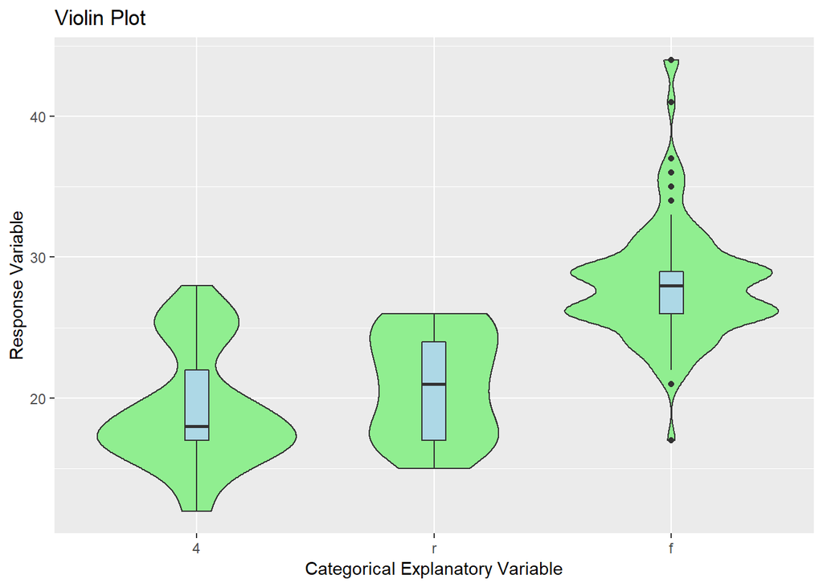

```r
violin_plot(mpg, "drv", "hwy")
```

### We can estimate a simple model with drive train as a predictor of highway miles per gallon. This is equivalent to an analysis of variance (ANOVA). We have a categorical predictor variable and no numerical predictor variables. The means that we have intercept terms in our regression equation and no slopes.

```r
zero_slope <- lm(hwy ~ drv, data = mpg)
zero_slope %>% summary()
```

```
##
## Call:
## lm(formula = hwy ~ drv, data = mpg)
##
## Residuals:
##     Min      1Q  Median      3Q     Max
## -11.160  -2.175  -1.000   1.960  15.840
##
## Coefficients:
##             Estimate Std. Error t value Pr(>|t|)
## (Intercept)  19.1748     0.4037  47.501   <2e-16 ***
## drvf          8.9856     0.5668  15.852   <2e-16 ***
## drvr          1.8252     0.9134   1.998   0.0469 *
## ---
## Signif. codes:  0 '***' 0.001 '**' 0.01 '*' 0.05 '.' 0.1 ' ' 1
##
## Residual standard error: 4.097 on 231 degrees of freedom
## Multiple R-squared:  0.5307, Adjusted R-squared:  0.5266
## F-statistic: 130.6 on 2 and 231 DF,  p-value: < 2.2e-16
```

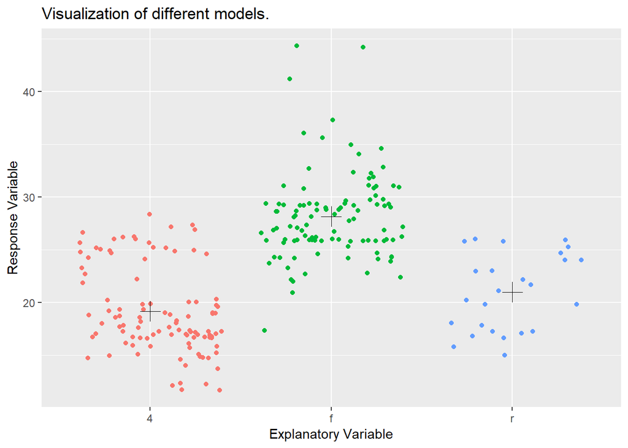

```r
graph_main_effects(mpg, zero_slope, "drv", "hwy")
```

### Is there a simple linear relationship between highway mileage and engine displacement? If so, then we have a good start on creating a model that will help us predict mpg conditional on engine displacement.

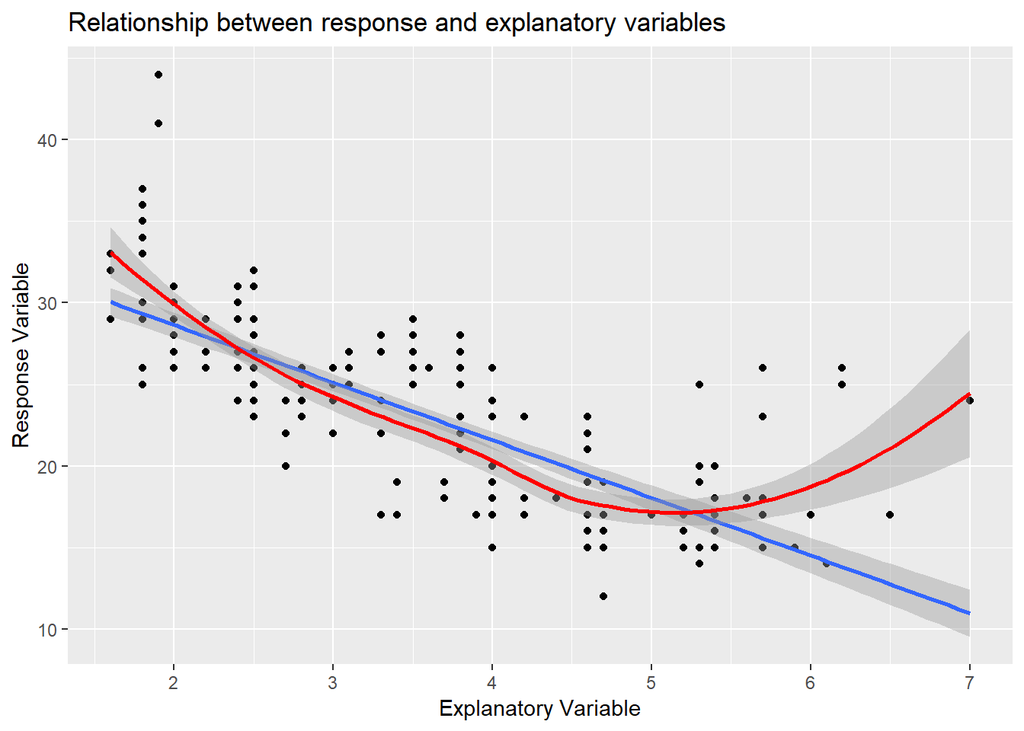

```r
relationship(mpg, "displ", "hwy")
```

### It is possible to have a common slope for displacement and different intercepts based on the type of drive train of vehicle. This is one version of an analysis of covariance model.

```r
common_slope <- lm(hwy ~ displ + drv, data = mpg)
common_slope %>% summary()
```

```
##
## Call:
## lm(formula = hwy ~ displ + drv, data = mpg)
##
## Residuals:
##     Min      1Q  Median      3Q     Max
## -8.9996 -1.9066 -0.3937  1.5778 13.9207
##
## Coefficients:
##             Estimate Std. Error t value Pr(>|t|)
## (Intercept)  30.8254     0.9239  33.364  < 2e-16 ***
## displ        -2.9141     0.2183 -13.352  < 2e-16 ***
## drvf          4.7906     0.5296   9.045  < 2e-16 ***
## drvr          5.2579     0.7336   7.167 1.03e-11 ***
## ---
## Signif. codes:  0 '***' 0.001 '**' 0.01 '*' 0.05 '.' 0.1 ' ' 1
##
## Residual standard error: 3.082 on 230 degrees of freedom
## Multiple R-squared:  0.7356, Adjusted R-squared:  0.7322
## F-statistic: 213.3 on 3 and 230 DF,  p-value: < 2.2e-16
```

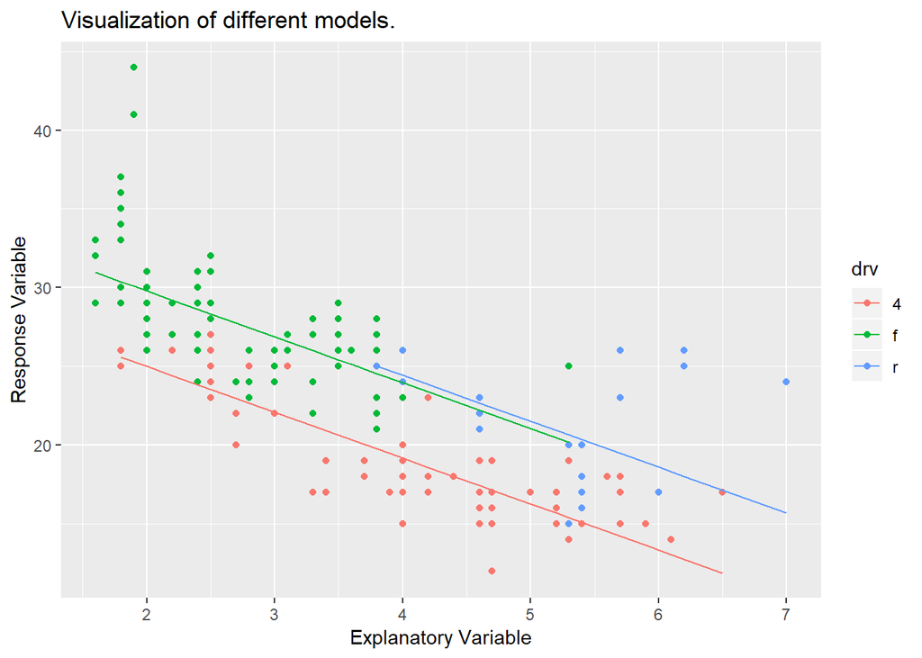

```r
graph_predictions(mpg, common_slope, "displ", "hwy", "drv")
```

### An analysis of covariance model also allows us to have both categorical and numerical variables as predictors. If we include an interaction term, then each category can have a different slope and intercept.

```r
different_slopes <- lm(hwy ~ displ + drv + displ * drv, data = mpg)
different_slopes %>% summary()
```

```
##
## Call:
## lm(formula = hwy ~ displ + drv + displ * drv, data = mpg)
##
## Residuals:
##    Min     1Q Median     3Q    Max
## -8.489 -1.895 -0.191  1.797 13.467
##
## Coefficients:
##             Estimate Std. Error t value Pr(>|t|)
## (Intercept)  30.6831     1.0961  27.994  < 2e-16 ***
## displ        -2.8785     0.2638 -10.913  < 2e-16 ***
## drvf          6.6950     1.5670   4.272 2.84e-05 ***
## drvr         -4.9034     4.1821  -1.172   0.2422
## displ:drvf   -0.7243     0.4979  -1.455   0.1471
## displ:drvr    1.9550     0.8148   2.400   0.0172 *
## ---
## Signif. codes:  0 '***' 0.001 '**' 0.01 '*' 0.05 '.' 0.1 ' ' 1
##
## Residual standard error: 3.034 on 228 degrees of freedom
## Multiple R-squared:  0.746,  Adjusted R-squared:  0.7405
## F-statistic:   134 on 5 and 228 DF,  p-value: < 2.2e-16
```

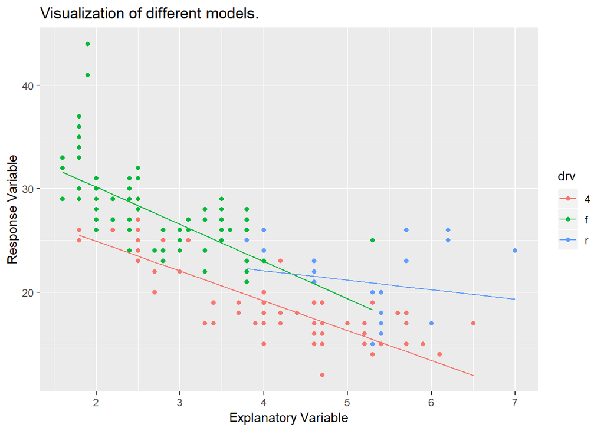

```r
graph_predictions(mpg, different_slopes, "displ", "hwy", "drv")
```

### We can now use the different_slopes model to predict the mileage of a car:

```r
different_slopes %>%
  predict(newdata = tibble(displ = c(2, 3.5), drv = c("4", "f")))
```

```
##        1        2
## 24.92614 24.76832
```